> **Tip**: Welcome to the Investigate a Dataset project! You will find tips in quoted sections like this to help organize your approach to your investigation. Before submitting your project, it will be a good idea to go back through your report and remove these sections to make the presentation of your work as tidy as possible. First things first, you might want to double-click this Markdown cell and change the title so that it reflects your dataset and investigation.

# Project: Investigate a Dataset (Medical Appointment No-Shows)

- Introduction
- Data Wrangling
- Exploratory Data Analysis
- Conclusions

## Introduction

> Every medical practice has appointment cancellations and no-shows. As a healthcare marketer, you must be aware of the high cost of no-shows and cancellations: decreased revenue, underutilized staff, lost commissions and decreased staff morale. If not addressed properly, appointment cancellations and no-shows can add up to revenue losses, estimates pointing to an average of $ 40,000 to $ 60,000 per year.

This is a dataset from the Brazilian Public Health System it consists of more than 100k appointments. 28.5% of the patients missed thier appoinment, the purpose of this investigation is to know why and what effect on this percentage.

**Data Dictionary** 1 - PatientId: Identification of a patient

2 - AppointmentID:Identification of each appointment

3 - Gender

4 - Age

5- Neighbourhood: Where the hospitals takes place.

6 - Scholarship

7 - Hipertension

8 - Diabetes

9- Alcoholism

10- Handcap

11- SMS_received

12- No-show : "Yes" means there is a no - show , "No" means the patient showed

**Questions to help in the investigation :**

1-What is the Percentage of patients who attend the appointment and the patients who missed it?

2- Does the gender effect on the ratio of the no-show , and if it effects which gender has more no-show?

3- Is age an influencing factor?

4- Which the illness diseases effect on the percentage of no-show?

5- Does the location of the hospitals(neighbourhood) effect on the 28.5% percentage?

6- Does sending SMS to the patients help in reducing the no-show ratio?

7- Does The appointment day effect on the 28.5% percentage?

8- Does the gab between the scheduled day and the appointment day effect on the no show ratio?

# Data Wrangling

## 1- Understand the Data / Investigation

```python
#set the environment
import pandas as pd
import numpy as np
import seaborn as sb
from matplotlib import pyplot as plt
%matplotlib inline
```

```python
#upload the data
df = pd.read_csv("noshow.csv")
```

```python
#check the dataset
df.head()
```

|  | PatientId | AppointmentID | Gender | ScheduledDay | AppointmentDay | Age | Neighbourhood | Scholarship | Hipertension | Diabetes | Alcoholism | Handcap | SMS_received | No-show |
| --- | --- | --- | --- | --- | --- | --- | --- | --- | --- | --- | --- | --- | --- | --- |
| 0 | 2.987250e+13 | 5642903 | F | 2016-04-29T18:38:08Z | 2016-04-29T00:00:00Z | 62 | JARDIM DA PENHA | 0 | 1 | 0 | 0 | 0 | 0 | No |
| 1 | 5.589980e+14 | 5642503 | M | 2016-04-29T16:08:27Z | 2016-04-29T00:00:00Z | 56 | JARDIM DA PENHA | 0 | 0 | 0 | 0 | 0 | 0 | No |
| 2 | 4.262960e+12 | 5642549 | F | 2016-04-29T16:19:04Z | 2016-04-29T00:00:00Z | 62 | MATA DA PRAIA | 0 | 0 | 0 | 0 | 0 | 0 | No |
| 3 | 8.679510e+11 | 5642828 | F | 2016-04-29T17:29:31Z | 2016-04-29T00:00:00Z | 8 | PONTAL DE CAMBURI | 0 | 0 | 0 | 0 | 0 | 0 | No |
| 4 | 8.841190e+12 | 5642494 | F | 2016-04-29T16:07:23Z | 2016-04-29T00:00:00Z | 56 | JARDIM DA PENHA | 0 | 1 | 1 | 0 | 0 | 0 | No |

```python
#nderstand more about the data
df.info()
```

```
<class 'pandas.core.frame.DataFrame'>
RangeIndex: 110527 entries, 0 to 110526
Data columns (total 14 columns):
PatientId         110527 non-null float64
AppointmentID     110527 non-null int64
Gender            110527 non-null object
ScheduledDay      110527 non-null object
AppointmentDay    110527 non-null object
Age               110527 non-null int64
Neighbourhood     110527 non-null object
Scholarship       110527 non-null int64
Hipertension      110527 non-null int64
Diabetes          110527 non-null int64
Alcoholism        110527 non-null int64
Handcap           110527 non-null int64
SMS_received      110527 non-null int64
No-show           110527 non-null object
dtypes: float64(1), int64(8), object(5)
memory usage: 11.8+ MB
```

**From the data info we can tell:**

The SechduledDay and AppointmentDay need to be converted to datetime.

```python
#Analyze the statical data for the dataset
df.describe()
```

|  | PatientId | AppointmentID | Age | Scholarship | Hipertension | Diabetes | Alcoholism | Handcap | SMS_received |
| --- | --- | --- | --- | --- | --- | --- | --- | --- | --- |
| count | 1.105270e+05 | 1.105270e+05 | 110527.000000 | 110527.000000 | 110527.000000 | 110527.000000 | 110527.000000 | 110527.000000 | 110527.000000 |
| mean | 1.474963e+14 | 5.675305e+06 | 37.088874 | 0.098266 | 0.197246 | 0.071865 | 0.030400 | 0.022248 | 0.321026 |
| std | 2.560949e+14 | 7.129575e+04 | 23.110205 | 0.297675 | 0.397921 | 0.258265 | 0.171686 | 0.161543 | 0.466873 |
| min | 3.920000e+04 | 5.030230e+06 | -1.000000 | 0.000000 | 0.000000 | 0.000000 | 0.000000 | 0.000000 | 0.000000 |
| 25% | 4.172615e+12 | 5.640286e+06 | 18.000000 | 0.000000 | 0.000000 | 0.000000 | 0.000000 | 0.000000 | 0.000000 |
| 50% | 3.173180e+13 | 5.680573e+06 | 37.000000 | 0.000000 | 0.000000 | 0.000000 | 0.000000 | 0.000000 | 0.000000 |
| 75% | 9.439170e+13 | 5.725524e+06 | 55.000000 | 0.000000 | 0.000000 | 0.000000 | 0.000000 | 0.000000 | 1.000000 |
| max | 9.999820e+14 | 5.790484e+06 | 115.000000 | 1.000000 | 1.000000 | 1.000000 | 1.000000 | 4.000000 | 1.000000 |

**The min age is -1 and the max age is 115 which is outliers , and it will be droped in the Data Cleaning section**

**We need to check the value count of the 3 deseases it seems like they are having just 0 and 1 values and for the Handcape 4 values**

```python
#before complete investigation I will lowercase the columns to make it easier
df.rename(columns=lambda x : x.strip().lower(), inplace=True)
```

```python
df.head(1)
```

|  | patientid | appointmentid | gender | scheduledday | appointmentday | age | neighbourhood | scholarship | hipertension | diabetes | alcoholism | handcap | sms_received | no-show |
| --- | --- | --- | --- | --- | --- | --- | --- | --- | --- | --- | --- | --- | --- | --- |
| 0 | 2.987250e+13 | 5642903 | F | 2016-04-29T18:38:08Z | 2016-04-29T00:00:00Z | 62 | JARDIM DA PENHA | 0 | 1 | 0 | 0 | 0 | 0 | No |

```python
#hypertension counts unique values
df.hipertension.value_counts()
```

```
0    88726
1    21801
Name: hipertension, dtype: int64
```

```python
#diabetes counts unique values
df.diabetes.value_counts()
```

```
0    102584
1      7943
Name: diabetes, dtype: int64
```

```python
#alcoholism counts unique values
df.alcoholism.value_counts()
```

```
0    107167
1      3360
Name: alcoholism, dtype: int64
```

```python
#handcap counts unique values
df.handcap.value_counts()
```

```
0    108286
1      2042
2       183
3        13
4         3
Name: handcap, dtype: int64
```

**In general, patients with no diseases in each disease are more than others**

```python
df.gender.value_counts()
```

```
F    71840
M    38687
Name: gender, dtype: int64
```

**In general, the number of females are higher than males , but the question is who has more no-show?**

```python
#Total number of unique observations over the index axis.
df.nunique()
```

```
patientid          61744
appointmentid     110527
gender                 2
scheduledday      103549
appointmentday        27
age                  104
neighbourhood         81
scholarship            2
hipertension           2
diabetes               2
alcoholism             2
handcap                5
sms_received           2
no-show                2
dtype: int64
```

**Some patients has more than record**

## 2- Data Cleaning

1- Check for missing rows

2- Check for duplicated data

3- Convert sechduleday and appointmentday to datetime

4- Drop age's outliers

5 - See the gab between the secheduleday and the appoinmentday to check if it effects the no-show ratio

7- Add two columns to divide the no-show column to attend patients and missing patients for further investigation

```python
# 1- check missing rows
df.isnull().sum().all()
```

```
False
```

```python
# 2- Check for duplicated data
sum(df.duplicated())
```

```
0
```

```python
# 3- Convert sechduleday and appointmentday to datetime
df["scheduledday"] = df["scheduledday"].astype("datetime64")
df["appointmentday"] = df["appointmentday"].astype("datetime64")
```

```python
#check if they are converted
df.info()
```

```
<class 'pandas.core.frame.DataFrame'>
RangeIndex: 110527 entries, 0 to 110526
Data columns (total 14 columns):
patientid         110527 non-null float64
appointmentid     110527 non-null int64
gender            110527 non-null object
scheduledday      110527 non-null datetime64[ns]
appointmentday    110527 non-null datetime64[ns]
age               110527 non-null int64
neighbourhood     110527 non-null object
scholarship       110527 non-null int64
hipertension      110527 non-null int64
diabetes          110527 non-null int64
alcoholism        110527 non-null int64
handcap           110527 non-null int64
sms_received      110527 non-null int64
no-show           110527 non-null object
dtypes: datetime64[ns](2), float64(1), int64(8), object(3)
memory usage: 11.8+ MB
```

```python
# 4 - query age's outliers
age_outliers = df.query("age < 0 | age == 115")
```

```python
#drop age's outliers
df.drop(index = age_outliers.index ,inplace=True)
```

```python
#check the age
df["age"].describe()
```

```
count    110521.000000
mean         37.085694
std          23.104606
min           0.000000
25%          18.000000
50%          37.000000
75%          55.000000
max         102.000000
Name: age, dtype: float64
```

```python
# 5- See the gab between the secheduleday and the appoinmentday and create a new column with it
df['gab'] = (df['appointmentday']- df['scheduledday']).dt.days
```

```python
#check the gab column
df.head()
```

|  | patientid | appointmentid | gender | scheduledday | appointmentday | age | neighbourhood | scholarship | hipertension | diabetes | alcoholism | handcap | sms_received | no-show | gab |
| --- | --- | --- | --- | --- | --- | --- | --- | --- | --- | --- | --- | --- | --- | --- | --- |
| 0 | 2.987250e+13 | 5642903 | F | 2016-04-29 18:38:08 | 2016-04-29 | 62 | JARDIM DA PENHA | 0 | 1 | 0 | 0 | 0 | 0 | No | -1 |
| 1 | 5.589980e+14 | 5642503 | M | 2016-04-29 16:08:27 | 2016-04-29 | 56 | JARDIM DA PENHA | 0 | 0 | 0 | 0 | 0 | 0 | No | -1 |
| 2 | 4.262960e+12 | 5642549 | F | 2016-04-29 16:19:04 | 2016-04-29 | 62 | MATA DA PRAIA | 0 | 0 | 0 | 0 | 0 | 0 | No | -1 |
| 3 | 8.679510e+11 | 5642828 | F | 2016-04-29 17:29:31 | 2016-04-29 | 8 | PONTAL DE CAMBURI | 0 | 0 | 0 | 0 | 0 | 0 | No | -1 |
| 4 | 8.841190e+12 | 5642494 | F | 2016-04-29 16:07:23 | 2016-04-29 | 56 | JARDIM DA PENHA | 0 | 1 | 1 | 0 | 0 | 0 | No | -1 |

```python
#gab counts unique values
df.gab.value_counts()
```

```
-1      38561
 1       6725
 3       5290
 0       5213
 6       4906
 5       4037
 4       3277
 13      2913
 2       2735
 7       2332
 20      1861
 27      1706
 12      1682
 8       1605
 14      1502
```

[output cut: 47 more lines]

```python
#filter the gabs less than 0
gab_outliers = df[df["gab"]<0]
```

```python
#drop the gab_outliers
df.drop(index=gab_outliers.index , inplace=True)
```

```python
#check gab counts unique values
df.gab.value_counts()
```

```
1      6725
3      5290
0      5213
6      4906
5      4037
4      3277
13     2913
2      2735
7      2332
20     1861
27     1706
12     1682
8      1605
14     1502
9      1391
```

[output cut: 47 more lines]

```python
df.head()
```

|  | patientid | appointmentid | gender | scheduledday | appointmentday | age | neighbourhood | scholarship | hipertension | diabetes | alcoholism | handcap | sms_received | no-show | gab |
| --- | --- | --- | --- | --- | --- | --- | --- | --- | --- | --- | --- | --- | --- | --- | --- |
| 5 | 9.598510e+13 | 5626772 | F | 2016-04-27 08:36:51 | 2016-04-29 | 76 | REPÚBLICA | 0 | 1 | 0 | 0 | 0 | 0 | No | 1 |
| 6 | 7.336880e+14 | 5630279 | F | 2016-04-27 15:05:12 | 2016-04-29 | 23 | GOIABEIRAS | 0 | 0 | 0 | 0 | 0 | 0 | Yes | 1 |
| 7 | 3.449830e+12 | 5630575 | F | 2016-04-27 15:39:58 | 2016-04-29 | 39 | GOIABEIRAS | 0 | 0 | 0 | 0 | 0 | 0 | Yes | 1 |
| 9 | 7.812460e+13 | 5629123 | F | 2016-04-27 12:48:25 | 2016-04-29 | 19 | CONQUISTA | 0 | 0 | 0 | 0 | 0 | 0 | No | 1 |
| 10 | 7.345360e+14 | 5630213 | F | 2016-04-27 14:58:11 | 2016-04-29 | 30 | NOVA PALESTINA | 0 | 0 | 0 | 0 | 0 | 0 | No | 1 |

```python
# 7- Add a column for weekday of the secheduleday to see later if it effects
df['weekday'] = df['appointmentday'].dt.day_name()
```

```python
#Check the new column
df.head(1)
```

|  | patientid | appointmentid | gender | scheduledday | appointmentday | age | neighbourhood | scholarship | hipertension | diabetes | alcoholism | handcap | sms_received | no-show | gab | weekday |
| --- | --- | --- | --- | --- | --- | --- | --- | --- | --- | --- | --- | --- | --- | --- | --- | --- |
| 5 | 9.598510e+13 | 5626772 | F | 2016-04-27 08:36:51 | 2016-04-29 | 76 | REPÚBLICA | 0 | 1 | 0 | 0 | 0 | 0 | No | 1 | Friday |

```python
df.info()
```

```
<class 'pandas.core.frame.DataFrame'>
Int64Index: 71955 entries, 5 to 110526
Data columns (total 16 columns):
patientid         71955 non-null float64
appointmentid     71955 non-null int64
gender            71955 non-null object
scheduledday      71955 non-null datetime64[ns]
appointmentday    71955 non-null datetime64[ns]
age               71955 non-null int64
neighbourhood     71955 non-null object
scholarship       71955 non-null int64
hipertension      71955 non-null int64
diabetes          71955 non-null int64
alcoholism        71955 non-null int64
handcap           71955 non-null int64
sms_received      71955 non-null int64
no-show           71955 non-null object
gab               71955 non-null int64
weekday           71955 non-null object
dtypes: datetime64[ns](2), float64(1), int64(9), object(4)
memory usage: 9.3+ MB
```

```python
#weekday unique value counts
df.weekday.value_counts()
```

```
Wednesday    17044
Tuesday      16462
Monday       14580
Friday       12515
Thursday     11323
Saturday        31
Name: weekday, dtype: int64
```

```python
#8- Add two columns to divide the no-show column to attend patients and missing patients for further investigation
attend = df['no-show'] == "No"
missing = df['no-show'] == "Yes"

df['attend'] = attend
df['missing'] = missing
```

```python
#check the two new columns
df.head()
```

|  | patientid | appointmentid | gender | scheduledday | appointmentday | age | neighbourhood | scholarship | hipertension | diabetes | alcoholism | handcap | sms_received | no-show | gab | weekday | attend | missing |
| --- | --- | --- | --- | --- | --- | --- | --- | --- | --- | --- | --- | --- | --- | --- | --- | --- | --- | --- |
| 5 | 9.598510e+13 | 5626772 | F | 2016-04-27 08:36:51 | 2016-04-29 | 76 | REPÚBLICA | 0 | 1 | 0 | 0 | 0 | 0 | No | 1 | Friday | True | False |
| 6 | 7.336880e+14 | 5630279 | F | 2016-04-27 15:05:12 | 2016-04-29 | 23 | GOIABEIRAS | 0 | 0 | 0 | 0 | 0 | 0 | Yes | 1 | Friday | False | True |
| 7 | 3.449830e+12 | 5630575 | F | 2016-04-27 15:39:58 | 2016-04-29 | 39 | GOIABEIRAS | 0 | 0 | 0 | 0 | 0 | 0 | Yes | 1 | Friday | False | True |
| 9 | 7.812460e+13 | 5629123 | F | 2016-04-27 12:48:25 | 2016-04-29 | 19 | CONQUISTA | 0 | 0 | 0 | 0 | 0 | 0 | No | 1 | Friday | True | False |
| 10 | 7.345360e+14 | 5630213 | F | 2016-04-27 14:58:11 | 2016-04-29 | 30 | NOVA PALESTINA | 0 | 0 | 0 | 0 | 0 | 0 | No | 1 | Friday | True | False |

**After cleaning lets check the new dataset**

```python
df.head()
```

|  | patientid | appointmentid | gender | scheduledday | appointmentday | age | neighbourhood | scholarship | hipertension | diabetes | alcoholism | handcap | sms_received | no-show | gab | weekday | attend | missing |
| --- | --- | --- | --- | --- | --- | --- | --- | --- | --- | --- | --- | --- | --- | --- | --- | --- | --- | --- |
| 5 | 9.598510e+13 | 5626772 | F | 2016-04-27 08:36:51 | 2016-04-29 | 76 | REPÚBLICA | 0 | 1 | 0 | 0 | 0 | 0 | No | 1 | Friday | True | False |
| 6 | 7.336880e+14 | 5630279 | F | 2016-04-27 15:05:12 | 2016-04-29 | 23 | GOIABEIRAS | 0 | 0 | 0 | 0 | 0 | 0 | Yes | 1 | Friday | False | True |
| 7 | 3.449830e+12 | 5630575 | F | 2016-04-27 15:39:58 | 2016-04-29 | 39 | GOIABEIRAS | 0 | 0 | 0 | 0 | 0 | 0 | Yes | 1 | Friday | False | True |
| 9 | 7.812460e+13 | 5629123 | F | 2016-04-27 12:48:25 | 2016-04-29 | 19 | CONQUISTA | 0 | 0 | 0 | 0 | 0 | 0 | No | 1 | Friday | True | False |
| 10 | 7.345360e+14 | 5630213 | F | 2016-04-27 14:58:11 | 2016-04-29 | 30 | NOVA PALESTINA | 0 | 0 | 0 | 0 | 0 | 0 | No | 1 | Friday | True | False |

```python
#dataset shape
df.shape
```

```
(71955, 18)
```

## Exploratory Data Analysis

### Research Question 1 : What is the Percentage of patients who attend the appointment and the patients who missed it?

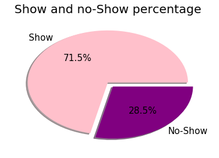

```python
#plot pie chart for the show and noshow count
df['no-show'].value_counts().plot(kind='pie',autopct='%1.1f%%' , fontsize=15,labels=['Show','No-Show'],explode=(.1 , 0) , colors = ["pink" , "purple"] , shadow = True);
plt.suptitle('Show and no-Show percentage ',fontsize=20)
plt.axis('off');
```

**As shown 71.5% of patients did not miss the appointment , and 28.5% miss their appointment.**

**The below exploration explan why this percentage exist.**

## Section 1: exploring the questions that with univariate variables

### Research Question 2 : Does the gender effect on the ratio of the no-show , and if it effects which gender has more no-show?

[figure not shown]

```python
#plot bar chart for the gender to compare between who attend and who missed /gender
plt.figure(figsize=(20,8))
plt.subplot(1,2,1)
ax = df["gender"][missing].value_counts(normalize=True).plot(kind='bar', color = "pink")
plt.title("The proportion of the patients who missed the appointment ratio to the gender")
plt.ylabel("Proportion")
plt.xlabel("Gender")
plt.legend( loc='upper right'  )

for p in ax.patches:
    width = p.get_width()
    height = p.get_height()
    x, y = p.get_xy()
    ax.annotate('{:0.1f}%'.format(height*100), (x + width/2, y + height*1.02), ha='center')

plt.subplot(1,2,2)

ay = df["gender"][attend].value_counts(normalize=True).plot(kind='bar', color = "pink")
plt.title("The proportion of the patients who attend the appointment ratio to the gender")
plt.ylabel("Proportion")
plt.xlabel("Gender")
plt.legend( loc='upper right'  )

for i in ay.patches:
    width_y = i.get_width()
    height_y = i.get_height()
    x, y = i.get_xy()
    ay.annotate('{:0.1f}%'.format(height*100), (x + width_y/2, y + height_y*1.02), ha='center')
```

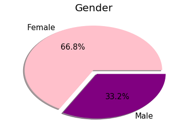

```python
#lets see the total percentage of the females to the males in the dataset
df['gender'].value_counts().plot(kind='pie',autopct='%1.1f%%' , fontsize=15,labels=['Female','Male'],explode=(.1 , 0) , colors = ["pink" , "purple"] , shadow = True);
plt.suptitle('Gender',fontsize=20)
plt.axis('off');
```

**The gender does not effect on the no-show but we can tell that females are taking care of thier health more than males**

### Research Question 3 :Is age an influencing factor ?

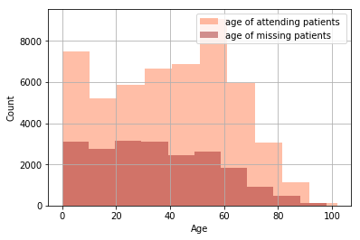

```python
#plot histogram for age
df["age"][attend].hist(alpha = 0.5 , label = "age of attending patients " , color = "coral" )
df["age"][missing].hist(alpha=0.5  , label = "age of missing patients " , color = "brown" )
plt.ylabel("Count")
plt.xlabel("Age")

plt.legend();
```

**The age effects on the no-show ratio, as the age increase the missing patients decrease , the range of approx. (50-60) has most attend count.**

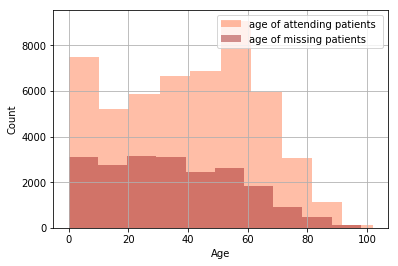

```python
#plot the age by ranges

df["age"][attend].hist(alpha = 0.5 , label = "age of attending patients " , color = "coral" )
df["age"][missing].hist(alpha=0.5  , label = "age of missing patients " , color = "brown" )
plt.ylabel("Count")
plt.xlabel("Age")

plt.legend();
```

### Research Question 4 :Which the illness diseases effect on the percentage of no-show ?

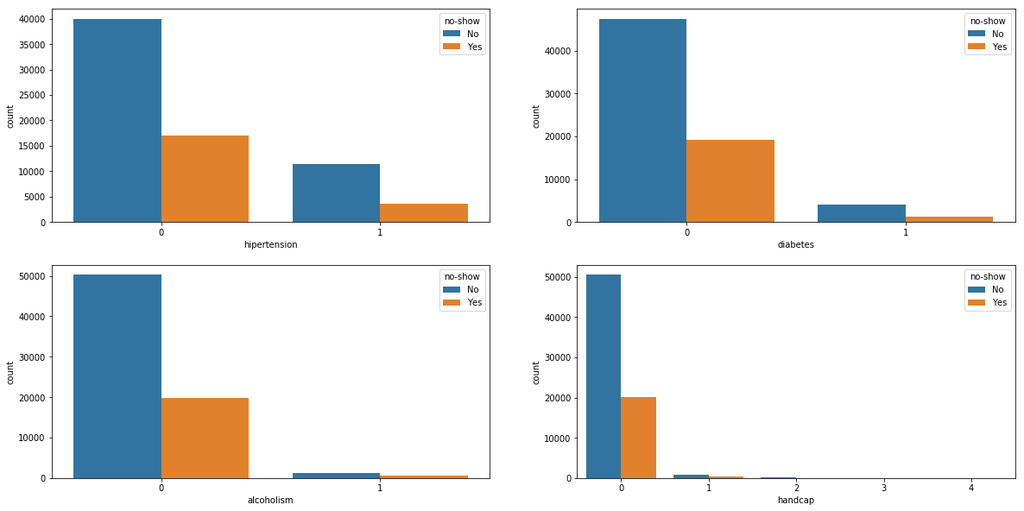

```python
#plot bar charts for (hipertension , diabetes , alcoholism ,handcap ) for both attend and missing
plt.figure(figsize = [20, 10])
plt.subplot(2, 2, 1)
sb.countplot(data = df, x = df["hipertension"], hue = df["no-show"] )
plt.subplot(2, 2, 2)
sb.countplot(data = df, x = df["diabetes"], hue = df["no-show"] )
plt.subplot(2, 2, 3)
sb.countplot(data = df, x = df["alcoholism"], hue = df["no-show"] )
plt.subplot(2, 2, 4)
sb.countplot(data = df, x = df["handcap"], hue = df["no-show"] )
```

**Note:"No" means patients attend (no-show) and "Yes" means patients did not attend**

**We can get a conclusion from the four graphs that number of patients without hipertension and diabetes are more likely to did'nt attend the appointment , but in general we can say that these four factors do not effect on the no-show percentage.**

### Research Question 5: Does the location of the hospitals(neighbourhood) effect on the 28.5% percentage ?

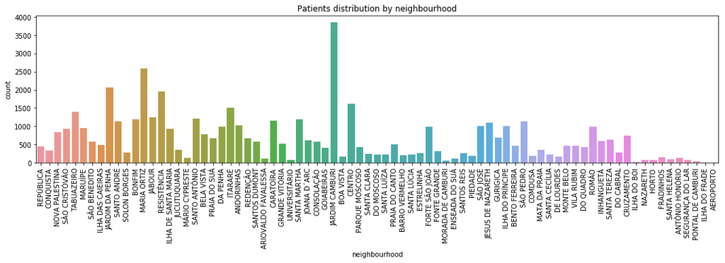

```python
#plot the neighbourhood for the attend section
plt.figure(figsize=(18,4))
plt.title('Patients distribution by neighbourhood')
sb.countplot(x=df["neighbourhood"][attend], data=df);
plt.xticks(rotation='90')
plt.show()
```

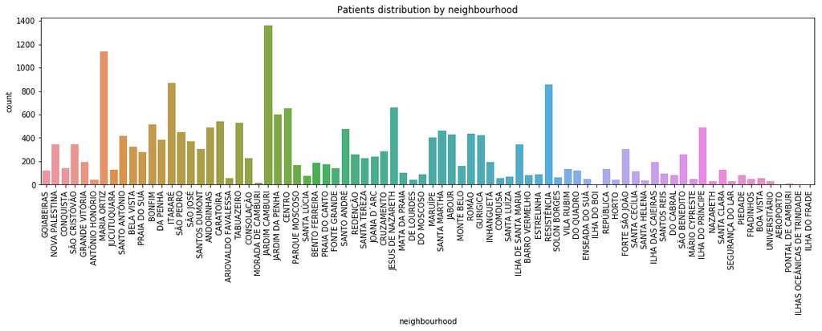

```python
#plot the neighbourhood for the missing section
plt.figure(figsize=(18,4))
plt.title('Patients distribution by neighbourhood')
sb.countplot(x=df["neighbourhood"][missing], data=df);
plt.xticks(rotation='90')
plt.show()
```

**Jardim Cumburi is the highest count for both show (attend) and noshow(missing) , but in general neighbourhood does not effect on the percentage**

### Research Question 6: Does sending SMS to the patients help in reducing the no-show ratio ?

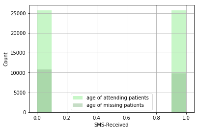

```python
df["sms_received"][attend].hist(alpha = 0.5 , label = "age of attending patients " , color = "lightgreen" )
df["sms_received"][missing].hist(alpha=0.5  , label = "age of missing patients " , color = "darkseagreen"  )
plt.ylabel("Count")
plt.xlabel("SMS-Received")
plt.legend( );
```

**Sending SMS to the patients doesn't reduce the no-show ratio**

### Research Question 7: Does The appointment day effect on the 28.5% percentage ?

```python
#replace No and Yes to 0 and 1
df["no-show"].replace(["Yes" , "No"], [1 , 0] , inplace= True)
```

```python
#check
df.head()
```

|  | patientid | appointmentid | gender | scheduledday | appointmentday | age | neighbourhood | scholarship | hipertension | diabetes | alcoholism | handcap | sms_received | no-show | gab | weekday | attend | missing |
| --- | --- | --- | --- | --- | --- | --- | --- | --- | --- | --- | --- | --- | --- | --- | --- | --- | --- | --- |
| 5 | 9.598510e+13 | 5626772 | F | 2016-04-27 08:36:51 | 2016-04-29 | 76 | REPÚBLICA | 0 | 1 | 0 | 0 | 0 | 0 | 0 | 1 | Friday | True | False |
| 6 | 7.336880e+14 | 5630279 | F | 2016-04-27 15:05:12 | 2016-04-29 | 23 | GOIABEIRAS | 0 | 0 | 0 | 0 | 0 | 0 | 1 | 1 | Friday | False | True |
| 7 | 3.449830e+12 | 5630575 | F | 2016-04-27 15:39:58 | 2016-04-29 | 39 | GOIABEIRAS | 0 | 0 | 0 | 0 | 0 | 0 | 1 | 1 | Friday | False | True |
| 9 | 7.812460e+13 | 5629123 | F | 2016-04-27 12:48:25 | 2016-04-29 | 19 | CONQUISTA | 0 | 0 | 0 | 0 | 0 | 0 | 0 | 1 | Friday | True | False |
| 10 | 7.345360e+14 | 5630213 | F | 2016-04-27 14:58:11 | 2016-04-29 | 30 | NOVA PALESTINA | 0 | 0 | 0 | 0 | 0 | 0 | 0 | 1 | Friday | True | False |

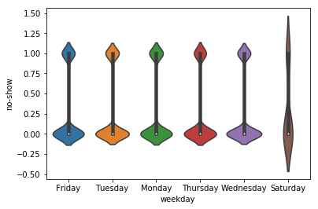

```python
#plot the weekday
sb.violinplot(data=df, x="weekday", y='no-show',  innner=None, figsize=(20,20))
```

**Saturday has the low show and no-show count , in the dataset it has 31 appoinments, and other days are crowded.**

## Section 2: exploring the questions that with bivariate variables

**Bivariate variables lies on the relationship between two variables so before answering the questions need to know the corr between the variables.**

```python
# get the correlation for all the numeric variables
df.corr()
```

|  | patientid | appointmentid | age | scholarship | hipertension | diabetes | alcoholism | handcap | sms_received | no-show | gab | attend | missing |
| --- | --- | --- | --- | --- | --- | --- | --- | --- | --- | --- | --- | --- | --- |
| patientid | 1.000000 | -0.003480 | -0.004810 | -0.001837 | -0.002624 | -0.000149 | 0.005213 | -0.003866 | -0.005480 | 0.003393 | 0.006273 | -0.003393 | 0.003393 |
| appointmentid | -0.003480 | 1.000000 | 0.019038 | 0.017538 | 0.043800 | 0.040149 | 0.025301 | 0.011397 | -0.083754 | -0.065720 | -0.788985 | 0.065720 | -0.065720 |
| age | -0.004810 | 0.019038 | 1.000000 | -0.103011 | 0.500901 | 0.284619 | 0.080405 | 0.076351 | -0.042461 | -0.101269 | -0.008601 | 0.101269 | -0.101269 |
| scholarship | -0.001837 | 0.017538 | -0.103011 | 1.000000 | -0.027764 | -0.025422 | 0.030527 | -0.010371 | 0.020658 | 0.045708 | -0.026179 | -0.045708 | 0.045708 |
| hipertension | -0.002624 | 0.043800 | 0.500901 | -0.027764 | 1.000000 | 0.425630 | 0.085825 | 0.083856 | -0.037116 | -0.056813 | -0.051124 | 0.056813 | -0.056813 |
| diabetes | -0.000149 | 0.040149 | 0.284619 | -0.025422 | 0.425630 | 1.000000 | 0.024171 | 0.061640 | -0.031228 | -0.022397 | -0.048248 | 0.022397 | -0.022397 |
| alcoholism | 0.005213 | 0.025301 | 0.080405 | 0.030527 | 0.085825 | 0.024171 | 1.000000 | 0.013555 | -0.009100 | 0.019874 | -0.029138 | -0.019874 | 0.019874 |
| handcap | -0.003866 | 0.011397 | 0.076351 | -0.010371 | 0.083856 | 0.061640 | 0.013555 | 1.000000 | -0.021863 | -0.007611 | -0.015863 | 0.007611 | -0.007611 |
| sms_received | -0.005480 | -0.083754 | -0.042461 | 0.020658 | -0.037116 | -0.031228 | -0.009100 | -0.021863 | 1.000000 | -0.020559 | 0.201797 | 0.020559 | -0.020559 |
| no-show | 0.003393 | -0.065720 | -0.101269 | 0.045708 | -0.056813 | -0.022397 | 0.019874 | -0.007611 | -0.020559 | 1.000000 | 0.060370 | -1.000000 | 1.000000 |
| gab | 0.006273 | -0.788985 | -0.008601 | -0.026179 | -0.051124 | -0.048248 | -0.029138 | -0.015863 | 0.201797 | 0.060370 | 1.000000 | -0.060370 | 0.060370 |
| attend | -0.003393 | 0.065720 | 0.101269 | -0.045708 | 0.056813 | 0.022397 | -0.019874 | 0.007611 | 0.020559 | -1.000000 | -0.060370 | 1.000000 | -1.000000 |
| missing | 0.003393 | -0.065720 | -0.101269 | 0.045708 | -0.056813 | -0.022397 | 0.019874 | -0.007611 | -0.020559 | 1.000000 | 0.060370 | -1.000000 | 1.000000 |

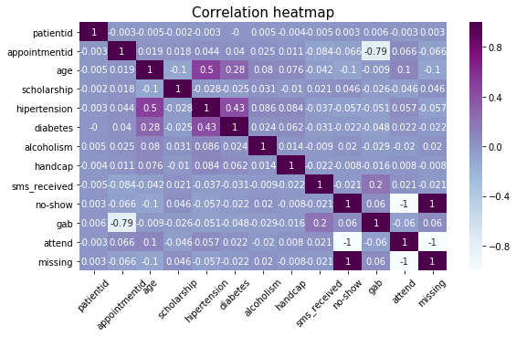

```python
#to see it better
plt.figure(figsize=(9,5))
sb.heatmap(df.corr().round(3), annot = True , cmap = 'BuPu')
plt.title('Correlation heatmap', size='15')

plt.xticks(rotation='45');
```

**Acording to the map there is a relation between age and hipertension = 0.5(low positive correlation )**

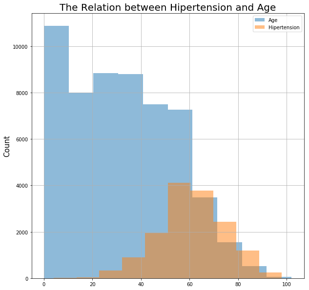

```python
#relationship between age and hipertension
plt.figure(figsize=(10,10))
df.groupby('hipertension').age.hist(alpha=0.5);
plt.title('The Relation between Hipertension and Age', fontsize=20)
plt.ylabel('Count', fontsize=15)
plt.legend(['Age','Hipertension'])
```

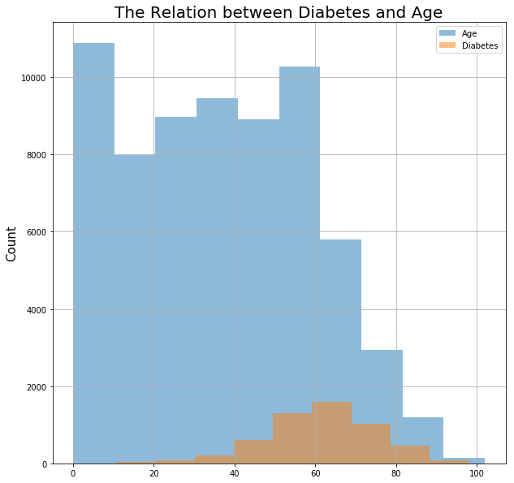

```python
#plot the relation between diabetes and age
plt.figure(figsize=(10,10))
df.groupby('diabetes').age.hist(alpha=0.5);
plt.title('The Relation between Diabetes and Age', fontsize=20)
plt.ylabel('Count', fontsize=15)
plt.legend(['Age','Diabetes'])
```

### Research Question 8: Does the gab between the scheduled day and the appointment day effect on the no show ratio?

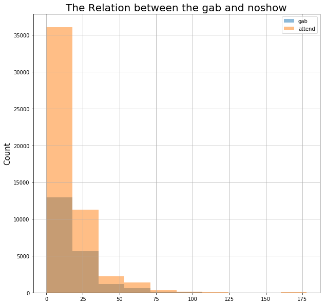

```python
#plot the relation between diabetes and age
plt.figure(figsize=(10,10))
df.groupby('attend').gab.hist(alpha=0.5);
plt.title('The Relation between the gab and noshow', fontsize=20)
plt.ylabel('Count', fontsize=15)
plt.legend(['gab','attend'])
```

**As the gab between the scheduled day and the appoinment day increase the number of attending patients decrease**

# Conclusion:

**After investigation we can tell the following:**

1- 71.5% of patients did not miss the appointment , and 28.5% miss their appointment.

2- The gender does not effect on the no-show but we can tell that females are taking care of thier health more than males The age effects on the no-show ratio, as the age increase the missing patients decrease , the range of approx. (50-60) has most attend count.

3- Number of patients without hipertension and diabetes are more likely to did'nt attend the appointment , but in general we can say that these four factors do not effect on the no-show percentage.

4- Jardim Cumburi is the highest count for both show (attend) and noshow(missing) , but in general neighbourhood does not effect on the percentage.

5- Sending SMS to the patients doesn't reduce the no-show ratio.

6- Saturday has the low show and no-show count , in the dataset it has 31 appoinments, and other days are crowded.

7- Acording to the map there is a relation between age and hipertension :low positive correlation Also there is a relation btween diabetes and age :very low positive correlation.

8- The heatmap shows that there is a strong negative relation between gab and appointment ID , and a very very weak negative relation between age and scholorship(-0.1).

9-As the gab between the scheduled day and the appoinment day increase the number of attending patients decrease.

# References

**The Data Visualization section in this course**

https://matplotlib.org/stable/tutorials/index.html

https://pandas.pydata.org/pandas-docs/stable/reference/api/pandas.DataFrame.html

```python
from subprocess import call
call(['python', '-m', 'nbconvert', 'Investigate_a_Dataset.ipynb'])
```

```
0
```